# Visualització gràfica d'un dataset

```python
import pandas as pd
import numpy as np
import matplotlib.pyplot as plt
import seaborn as sns
```

### Exercici 1

Resumeix gràficament el data set DelayedFlights.csv

Crea almenys una visualització per:

- Una variable categòrica (UniqueCarrier)
- Una variable numèrica (ArrDelay)
- Una variable numèrica i una categòrica (ArrDelay i UniqueCarrier)
- Dues variables numèriques (ArrDelay i DepDelay)
- Tres variables (ArrDelay, DepDelay i UniqueCarrier)
- Més de tres variables (ArrDelay, DepDelay, AirTime i UniqueCarrier).

### Exercici 2

Exporta els gràfics com imatges o com html.

### Exercici 3

Exporta el data set net i amb les noves columnes a Excel.

### Exercici 4

Integra les visualitzacions gràfiques, en la tasca 5, del Sprint 3.

# Data:

[Airlines Delay: Airline on-time statistics and delay causes](https://www.kaggle.com/giovamata/airlinedelaycauses)

```python
## Import dataset
df_raw = pd.read_csv("archive/DelayedFlights.csv", index_col = 0)
```

```python
## Columns and Data types
df_raw.info(show_counts = True)
```

```
<class 'pandas.core.frame.DataFrame'>
Int64Index: 1936758 entries, 0 to 7009727
Data columns (total 29 columns):
 #   Column             Non-Null Count    Dtype
---  ------             --------------    -----
 0   Year               1936758 non-null  int64
 1   Month              1936758 non-null  int64
 2   DayofMonth         1936758 non-null  int64
 3   DayOfWeek          1936758 non-null  int64
 4   DepTime            1936758 non-null  float64
 5   CRSDepTime         1936758 non-null  int64
 6   ArrTime            1929648 non-null  float64
 7   CRSArrTime         1936758 non-null  int64
 8   UniqueCarrier      1936758 non-null  object
 9   FlightNum          1936758 non-null  int64
```

[output cut: 21 more lines]

#### Variable descriptions:

- Year: 1987-2008
- Month: 1-12
- DayofMonth: 1-31
- DayOfWeek: 1 (Monday) - 7 (Sunday)
- DepTime: departure time (local, hhmm)
- CRSDepTime: scheduled departure time (local, hhmm)
- ArrTime: arrival time (local, hhmm)
- CRSArrTime: scheduled arrival time (local, hhmm)
- UniqueCarrier: unique carrier code
- FlightNum: flight number
- TailNum: plane tail number
- ActualElapsedTime: flygth time in minutes (Total)
- CRSElapsedTime: scheduled flygth time in minutes (Total)
- AirTime: time on air in minutes
- ArrDelay: arrival delay in minutes
- DepDelay: departure delay in minutes
- Origin: origin IATA airport code
- Dest: destination IATA airport code
- Distance: distance in miles
- TaxiIn: taxi in time, in minutes (movement on ground)
- TaxiOut: taxi out time, in minutes (movement on ground)
- Cancelled: was the flight cancelled?
- CancellationCode: [reason for cancellation](https://aspmhelp.faa.gov/index/Types_of_Delay.html) (A = carrier, B = weather, C = NAS, D = security)
- Diverted: 1 = yes, 0 = no ("Desviado")
- CarrierDelay: delayed time due to Carrier in minutes
- WeatherDelay: delayed time due to Weather in minutes
- NASDelay: delayed time due to NAS in minutes
- SecurityDelay: delayed time due to security in minuts
- LateAircraftDelay: delayed time due to late aircraft in minutes

```python
## Dataframe Visualization
pd.set_option('display.max_columns', None)
```

```python
## Sample
df_raw.sample(10)
```

|  | Year | Month | DayofMonth | DayOfWeek | DepTime | CRSDepTime | ArrTime | CRSArrTime | UniqueCarrier | FlightNum | TailNum | ActualElapsedTime | CRSElapsedTime | AirTime | ArrDelay | DepDelay | Origin | Dest | Distance | TaxiIn | TaxiOut | Cancelled | CancellationCode | Diverted | CarrierDelay | WeatherDelay | NASDelay | SecurityDelay | LateAircraftDelay |
| --- | --- | --- | --- | --- | --- | --- | --- | --- | --- | --- | --- | --- | --- | --- | --- | --- | --- | --- | --- | --- | --- | --- | --- | --- | --- | --- | --- | --- | --- |
| 1122251 | 2008 | 2 | 9 | 6 | 1716.0 | 1700 | 2033.0 | 2005 | B6 | 21 | N553JB | 197.0 | 185.0 | 165.0 | 28.0 | 16.0 | JFK | TPA | 1005 | 7.0 | 25.0 | 0 | N | 0 | 0.0 | 0.0 | 12.0 | 0.0 | 16.0 |
| 2553769 | 2008 | 5 | 27 | 2 | 650.0 | 620 | 850.0 | 807 | OH | 5121 | N548CA | 120.0 | 107.0 | 80.0 | 43.0 | 30.0 | PHL | CVG | 507 | 10.0 | 30.0 | 0 | N | 0 | 30.0 | 0.0 | 13.0 | 0.0 | 0.0 |
| 3099169 | 2008 | 6 | 5 | 4 | 1309.0 | 1130 | 1700.0 | 1510 | XE | 2846 | N13913 | 171.0 | 160.0 | 146.0 | 110.0 | 99.0 | IAH | RDU | 1043 | 6.0 | 19.0 | 0 | N | 0 | 99.0 | 0.0 | 11.0 | 0.0 | 0.0 |
| 6683150 | 2008 | 12 | 14 | 7 | 909.0 | 857 | 1233.0 | 1219 | UA | 910 | N593UA | 144.0 | 142.0 | 106.0 | 14.0 | 12.0 | DEN | ORD | 888 | 4.0 | 34.0 | 0 | N | 0 | NaN | NaN | NaN | NaN | NaN |
| 5126330 | 2008 | 9 | 26 | 5 | 1350.0 | 1340 | 1522.0 | 1512 | DL | 138 | N757AT | 92.0 | 92.0 | 64.0 | 10.0 | 10.0 | TPA | ATL | 406 | 10.0 | 18.0 | 0 | N | 0 | NaN | NaN | NaN | NaN | NaN |
| 263519 | 2008 | 1 | 6 | 7 | 1109.0 | 1051 | 1640.0 | 1635 | US | 149 | N821AW | 211.0 | 224.0 | 187.0 | 5.0 | 18.0 | PHX | CMH | 1671 | 7.0 | 17.0 | 0 | N | 0 | NaN | NaN | NaN | NaN | NaN |
| 6892136 | 2008 | 12 | 2 | 2 | 632.0 | 625 | 735.0 | 730 | 9E | 2954 | 85329E | 63.0 | 65.0 | 36.0 | 5.0 | 7.0 | SBN | DTW | 157 | 8.0 | 19.0 | 0 | N | 0 | NaN | NaN | NaN | NaN | NaN |
| 3294792 | 2008 | 6 | 1 | 7 | 2025.0 | 1955 | 2250.0 | 2210 | WN | 904 | N306SW | 145.0 | 135.0 | 117.0 | 40.0 | 30.0 | MCO | PIT | 834 | 6.0 | 22.0 | 0 | N | 0 | 0.0 | 30.0 | 10.0 | 0.0 | 0.0 |
| 589819 | 2008 | 1 | 2 | 3 | 2012.0 | 2005 | 2203.0 | 2143 | DL | 1226 | N951DL | 111.0 | 98.0 | 72.0 | 20.0 | 7.0 | ATL | PHF | 508 | 5.0 | 34.0 | 0 | N | 0 | 0.0 | 0.0 | 13.0 | 0.0 | 7.0 |
| 4256084 | 2008 | 8 | 9 | 6 | 1716.0 | 1700 | 2300.0 | 2255 | WN | 1966 | N288WN | 224.0 | 235.0 | 204.0 | 5.0 | 16.0 | SEA | MDW | 1733 | 8.0 | 12.0 | 0 | N | 0 | NaN | NaN | NaN | NaN | NaN |

# Data Transformation:

```python
## Copy DF
df_trans = df_raw.copy()
```

#### Duplicates:

```python
## Search Duplicates
print ("Duplicates: ", df_trans.duplicated().sum())
df_trans[df_trans.duplicated(keep = False)]
```

```
Duplicates:  2
```

|  | Year | Month | DayofMonth | DayOfWeek | DepTime | CRSDepTime | ArrTime | CRSArrTime | UniqueCarrier | FlightNum | TailNum | ActualElapsedTime | CRSElapsedTime | AirTime | ArrDelay | DepDelay | Origin | Dest | Distance | TaxiIn | TaxiOut | Cancelled | CancellationCode | Diverted | CarrierDelay | WeatherDelay | NASDelay | SecurityDelay | LateAircraftDelay |
| --- | --- | --- | --- | --- | --- | --- | --- | --- | --- | --- | --- | --- | --- | --- | --- | --- | --- | --- | --- | --- | --- | --- | --- | --- | --- | --- | --- | --- | --- |
| 938224 | 2008 | 2 | 28 | 4 | 1854.0 | 1807 | 1946.0 | 1902 | F9 | 773 | N201FR | 112.0 | 115.0 | 91.0 | 44.0 | 47.0 | DEN | LAS | 629 | 8.0 | 13.0 | 0 | N | 0 | 44.0 | 0.0 | 0.0 | 0.0 | 0.0 |
| 938225 | 2008 | 2 | 28 | 4 | 1854.0 | 1807 | 1946.0 | 1902 | F9 | 773 | N201FR | 112.0 | 115.0 | 91.0 | 44.0 | 47.0 | DEN | LAS | 629 | 8.0 | 13.0 | 0 | N | 0 | 44.0 | 0.0 | 0.0 | 0.0 | 0.0 |
| 938226 | 2008 | 2 | 28 | 4 | 2027.0 | 1942 | 2314.0 | 2229 | F9 | 780 | N201FR | 107.0 | 107.0 | 84.0 | 45.0 | 45.0 | LAS | DEN | 629 | 10.0 | 13.0 | 0 | N | 0 | 1.0 | 0.0 | 44.0 | 0.0 | 0.0 |
| 938227 | 2008 | 2 | 28 | 4 | 2027.0 | 1942 | 2314.0 | 2229 | F9 | 780 | N201FR | 107.0 | 107.0 | 84.0 | 45.0 | 45.0 | LAS | DEN | 629 | 10.0 | 13.0 | 0 | N | 0 | 1.0 | 0.0 | 44.0 | 0.0 | 0.0 |

```python
## Drop Duplicates
df_trans.drop_duplicates(inplace = True)
```

#### Null Values:

```python
## Null Values %
df_trans.isnull().mean()*100
```

```
Year                  0.000000
Month                 0.000000
DayofMonth            0.000000
DayOfWeek             0.000000
DepTime               0.000000
CRSDepTime            0.000000
ArrTime               0.367109
CRSArrTime            0.000000
UniqueCarrier         0.000000
FlightNum             0.000000
TailNum               0.000258
ActualElapsedTime     0.433044
CRSElapsedTime        0.010223
AirTime               0.433044
ArrDelay              0.433044
DepDelay              0.000000
Origin                0.000000
Dest                  0.000000
Distance              0.000000
TaxiIn                0.367109
TaxiOut               0.023493
Cancelled             0.000000
CancellationCode      0.000000
Diverted              0.000000
CarrierDelay         35.588892
WeatherDelay         35.588892
NASDelay             35.588892
SecurityDelay        35.588892
LateAircraftDelay    35.588892
dtype: float64
```

```python
## Columns with low percentage of nulls (less than 2% in total)
subset = ["ArrTime", "TailNum", "ActualElapsedTime", "CRSElapsedTime", "AirTime",
                           "ArrDelay", "TaxiIn", "TaxiOut"]
```

```python
## Save rows with low percentage of nulls before drop
df_null = df_trans[df_trans[subset].isnull().any(axis=1)]
```

```python
## Drop rows with low percentage of nulls
df_trans = df_trans.dropna(subset=subset)
```

We could set the nulls in the **Delay** columns equal to the median or equal to zero. If equal to **zero**, assuming that nulls in these columns correspond to absence of delay, we should filter those rows before extracting information to avoid bias. However, I'm not sure that nulls mean zero delay, maybe are just unknown information, which will explain why they have identical null percentage if all these observations come front the same font. We could set the nulls equal to the **median**, but in this case I rather prefer leaving the dataframe as it is right now, since nulls do not interfer with the statistics we are going to infer.

#### Clean Time:

```python
## Transform DepTime and ArrTime to a more consistent notation (hh:mm)
df_trans["DepTime"] = df_trans["DepTime"].astype(int).apply(lambda x: str(x).zfill(4)).apply(lambda x: x[0:2] + ":" + x[2:])
df_trans["CRSDepTime"] = df_trans["CRSDepTime"].astype(int).apply(lambda x: str(x).zfill(4)).apply(lambda x: x[0:2] + ":" + x[2:])
df_trans["ArrTime"] = df_trans["ArrTime"].astype(int).apply(lambda x: str(x).zfill(4)).apply(lambda x: x[0:2] + ":" + x[2:])
df_trans["CRSArrTime"] = df_trans["CRSArrTime"].astype(int).apply(lambda x: str(x).zfill(4)).apply(lambda x: x[0:2] + ":" + x[2:])
```

#### Describe:

```python
## Change dtypes
df_trans["FlightNum"] = df_trans["FlightNum"].astype(str)
df_trans["Cancelled"] = df_trans["Cancelled"].astype(str)
df_trans["Diverted"] = df_trans["Diverted"].astype(str)
```

```python
## Divide into numerical and categorical
df_num = df_trans.select_dtypes(include = ["int64", "float64"])
df_cat = df_trans.select_dtypes(exclude = ["int64", "float64"])
```

```python
## Describe num
df_num.describe().round(2)
```

|  | Year | Month | DayofMonth | DayOfWeek | ActualElapsedTime | CRSElapsedTime | AirTime | ArrDelay | DepDelay | Distance | TaxiIn | TaxiOut | CarrierDelay | WeatherDelay | NASDelay | SecurityDelay | LateAircraftDelay |
| --- | --- | --- | --- | --- | --- | --- | --- | --- | --- | --- | --- | --- | --- | --- | --- | --- | --- |
| count | 1928366.0 | 1928366.00 | 1928366.00 | 1928366.00 | 1928366.00 | 1928366.00 | 1928366.00 | 1928366.00 | 1928366.00 | 1928366.00 | 1928366.00 | 1928366.00 | 1247484.00 | 1247484.00 | 1247484.00 | 1247484.00 | 1247484.00 |
| mean | 2008.0 | 6.11 | 15.75 | 3.98 | 133.31 | 134.20 | 108.28 | 42.20 | 43.09 | 764.95 | 6.81 | 18.22 | 19.18 | 3.70 | 15.02 | 0.09 | 25.30 |
| std | 0.0 | 3.48 | 8.78 | 2.00 | 72.06 | 71.23 | 68.64 | 56.78 | 53.27 | 573.89 | 5.27 | 14.31 | 43.55 | 21.49 | 33.83 | 2.02 | 42.05 |
| min | 2008.0 | 1.00 | 1.00 | 1.00 | 14.00 | -21.00 | 0.00 | -109.00 | 6.00 | 11.00 | 0.00 | 0.00 | 0.00 | 0.00 | 0.00 | 0.00 | 0.00 |
| 25% | 2008.0 | 3.00 | 8.00 | 2.00 | 80.00 | 82.00 | 58.00 | 9.00 | 12.00 | 338.00 | 4.00 | 10.00 | 0.00 | 0.00 | 0.00 | 0.00 | 0.00 |
| 50% | 2008.0 | 6.00 | 16.00 | 4.00 | 116.00 | 116.00 | 90.00 | 24.00 | 24.00 | 606.00 | 6.00 | 14.00 | 2.00 | 0.00 | 2.00 | 0.00 | 8.00 |
| 75% | 2008.0 | 9.00 | 23.00 | 6.00 | 165.00 | 165.00 | 137.00 | 56.00 | 53.00 | 997.00 | 8.00 | 21.00 | 21.00 | 0.00 | 15.00 | 0.00 | 33.00 |
| max | 2008.0 | 12.00 | 31.00 | 7.00 | 1114.00 | 660.00 | 1091.00 | 2461.00 | 2467.00 | 4962.00 | 240.00 | 422.00 | 2436.00 | 1352.00 | 1357.00 | 392.00 | 1316.00 |

- **std of Year = 0.** All flygths are in 2008. Does not give any information.

```python
## Drop Year
df_trans.drop(columns = "Year", inplace = True)
```

```python
## Describe cat
df_cat.describe()
```

|  | DepTime | CRSDepTime | ArrTime | CRSArrTime | UniqueCarrier | FlightNum | TailNum | Origin | Dest | Cancelled | CancellationCode | Diverted |
| --- | --- | --- | --- | --- | --- | --- | --- | --- | --- | --- | --- | --- |
| count | 1928366 | 1928366 | 1928366 | 1928366 | 1928366 | 1928366 | 1928366 | 1928366 | 1928366 | 1928366 | 1928366 | 1928366 |
| unique | 1438 | 1193 | 1440 | 1361 | 20 | 7498 | 5360 | 303 | 302 | 1 | 1 | 1 |
| top | 18:00 | 18:00 | 21:00 | 19:30 | WN | 16 | N325SW | ATL | ORD | 0 | N | 0 |
| freq | 3176 | 13867 | 2981 | 9148 | 376201 | 1575 | 961 | 131213 | 108265 | 1928366 | 1928366 | 1928366 |

- **unique of *Cancelled*, *CancellationCode* and *Diverted* are equal to 1.** These columns do not give any information. Any flygth has been cancelled ore diverted.

```python
## Drop Cancelled, CancellationCode and Diverted
df_trans.drop(columns = ["Cancelled", "CancellationCode", "Diverted"], inplace = True)
```

# Feature Engineering:

```python
## Categorical column with delay > 15 min (1 = Yes, 0 = No)
df_trans["DelayCat"] = df_trans["ArrDelay"].apply(lambda x: 1 if x > 15 else 0)
```

```python
## Mean Velocity columns in miles/min
df_trans["Velocity"] = df_trans["Distance"] / df_trans["AirTime"]
```

```python
## Origin-Destination Columns
df_trans["Fligth"] = df_trans["Origin"] + "-" + df_trans["Dest"]
```

# Save Data:

```python
## Save Final Dataframe
df_trans.to_csv("df_clean.csv")
```

# Plots:

```python
## Import Clean data
df = pd.read_csv("df_clean.csv", index_col = 0)
```

```python
## Sample
df.sample(10)
```

|  | Month | DayofMonth | DayOfWeek | DepTime | CRSDepTime | ArrTime | CRSArrTime | UniqueCarrier | FlightNum | TailNum | ActualElapsedTime | CRSElapsedTime | AirTime | ArrDelay | DepDelay | Origin | Dest | Distance | TaxiIn | TaxiOut | CarrierDelay | WeatherDelay | NASDelay | SecurityDelay | LateAircraftDelay | DelayCat | Velocity | Fligth |
| --- | --- | --- | --- | --- | --- | --- | --- | --- | --- | --- | --- | --- | --- | --- | --- | --- | --- | --- | --- | --- | --- | --- | --- | --- | --- | --- | --- | --- |
| 3574071 | 6 | 14 | 6 | 17:09 | 16:40 | 21:23 | 19:58 | CO | 1820 | N14609 | 194.0 | 138.0 | 107.0 | 85.0 | 29.0 | IAH | ATL | 689 | 58.0 | 29.0 | 0.0 | 0.0 | 56.0 | 0.0 | 29.0 | 1 | 6.439252 | IAH-ATL |
| 6051740 | 11 | 2 | 7 | 08:07 | 08:00 | 09:16 | 09:12 | XE | 2349 | N13913 | 69.0 | 72.0 | 53.0 | 4.0 | 7.0 | BTR | IAH | 253 | 7.0 | 9.0 | NaN | NaN | NaN | NaN | NaN | 0 | 4.773585 | BTR-IAH |
| 6949764 | 12 | 18 | 4 | 22:18 | 21:31 | 00:35 | 23:48 | AS | 621 | N514AS | 137.0 | 137.0 | 116.0 | 47.0 | 47.0 | LAS | PDX | 762 | 3.0 | 18.0 | 0.0 | 0.0 | 0.0 | 0.0 | 47.0 | 1 | 6.568966 | LAS-PDX |
| 4198208 | 7 | 20 | 7 | 17:55 | 17:15 | 20:44 | 20:19 | CO | 1693 | N17139 | 169.0 | 184.0 | 146.0 | 25.0 | 40.0 | MCO | EWR | 938 | 10.0 | 13.0 | 0.0 | 0.0 | 25.0 | 0.0 | 0.0 | 1 | 6.424658 | MCO-EWR |
| 5396649 | 10 | 6 | 1 | 11:19 | 11:05 | 13:00 | 12:45 | WN | 1174 | N505SW | 101.0 | 100.0 | 88.0 | 15.0 | 14.0 | STL | DAL | 546 | 4.0 | 9.0 | 0.0 | 0.0 | 1.0 | 0.0 | 14.0 | 0 | 6.204545 | STL-DAL |
| 4758019 | 8 | 8 | 5 | 20:09 | 18:10 | 22:02 | 20:10 | AA | 1973 | N5FGAA | 173.0 | 180.0 | 150.0 | 112.0 | 119.0 | MIA | DFW | 1121 | 6.0 | 17.0 | 53.0 | 0.0 | 0.0 | 0.0 | 59.0 | 1 | 7.473333 | MIA-DFW |
| 2810960 | 5 | 12 | 1 | 18:50 | 17:10 | 20:45 | 19:00 | MQ | 4918 | N704PG | 115.0 | 110.0 | 86.0 | 105.0 | 100.0 | CMH | LGA | 478 | 10.0 | 19.0 | 93.0 | 0.0 | 5.0 | 0.0 | 7.0 | 1 | 5.558140 | CMH-LGA |
| 4403316 | 8 | 29 | 5 | 19:00 | 18:35 | 20:20 | 19:51 | OH | 5665 | N528CA | 80.0 | 76.0 | 53.0 | 29.0 | 25.0 | PIT | CVG | 256 | 5.0 | 22.0 | 0.0 | 25.0 | 4.0 | 0.0 | 0.0 | 1 | 4.830189 | PIT-CVG |
| 4060700 | 7 | 3 | 4 | 12:56 | 12:00 | 18:10 | 17:18 | NW | 780 | N360NB | 194.0 | 198.0 | 160.0 | 52.0 | 56.0 | LAS | MSP | 1300 | 9.0 | 25.0 | 0.0 | 0.0 | 0.0 | 0.0 | 52.0 | 1 | 8.125000 | LAS-MSP |
| 840356 | 2 | 15 | 5 | 11:07 | 09:45 | 12:26 | 11:15 | UA | 1197 | N848UA | 139.0 | 150.0 | 115.0 | 71.0 | 82.0 | DEN | LAX | 862 | 13.0 | 11.0 | 5.0 | 0.0 | 0.0 | 0.0 | 66.0 | 1 | 7.495652 | DEN-LAX |

#### Pie Chart:

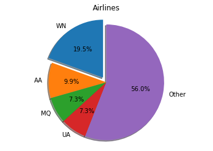

```python
## Pie chart of UniqueCarrier using Matplotlib

main_sizes = list(df["UniqueCarrier"].value_counts()[:4])
other_sizes = df["UniqueCarrier"].value_counts()[4:].sum()
main_sizes.append(other_sizes)

main_labels = list(df["UniqueCarrier"].value_counts().index[:4])
labels = main_labels.append("Other")

fig1, ax1 = plt.subplots()
plt.title("Airlines")

ax1.pie(main_sizes, labels = main_labels, explode = [0.1, 0, 0, 0, 0], autopct='%1.1f%%',
        shadow=True, startangle=90)
ax1.axis('equal')  # Equal aspect ratio ensures that pie is drawn as a circle.

plt.savefig('PieChart.png')
```

#### Bar Plot:

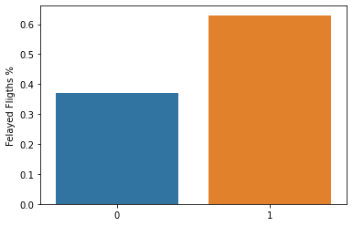

```python
## BarPlot with Seaborn %
percentage = df["DelayCat"].value_counts()/df["DelayCat"].value_counts().sum()
ax = sns.barplot(x = df["DelayCat"].value_counts().index, y = percentage);
ax.set_ylabel("Felayed Fligths %");
```

#### Histogram:

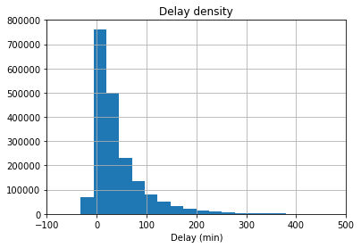

```python
## Histogram with pandas
ax = df.ArrDelay.hist(bins = 100);
ax.set(xlim=(-100, 500));
ax.set_xlabel("Delay (min)");
ax.set_title("Delay density");
```